# Statistics with R

Gene set comparison and enrichment analysis

2021-03-29

# Two main approches

- Gene set comparison or over-representation analysis (ORA)
  - Input: a set of functionally related genes
  - Reference: a database of annotated gene functions (GO, pathways, TF targets…)
  - Approach: evaluate the significance of the intersection (over-represented?)
  - Stat: hypergeometric test
- Gene Set Enrichment analysis
  - Input: a sorted list of genes
  - Reference: a database of annotated gene functions (GO, pathways, TF targets…)
  - Approach: evaluate the significance of the rank of the genes belonging to a reference class in the ordered list.
  - Stat: enrichment scores (alternative)

# Gene set comparison (over-representation of the intersection)

- A given organism has 6000 genes, 40 of which are involved in methionine metabolism.
- A set of 10 genes were reported as co-expressed in an RNAseq experiment. Among them, 6 are related to methionine metabolism.
- How significant is this observation ? More precisely, what would be the probability to observe such a correspondence by chance alone ?

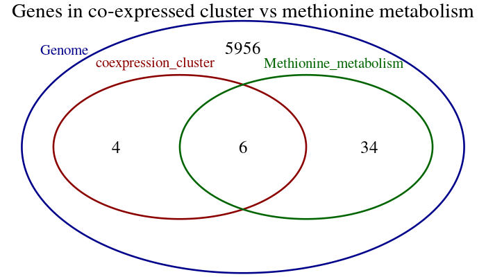

# The hypergeometric test

| Symbol | Meaning |
| --- | --- |
| $g = 6000$ | number of genes |
| $m = 40$ | genes involved in methionine metabolism |
| $n = 5960$ | genes not involved in methionine metabolism |
| $k = 10$ | number of genes in the cluster |
| $x = 6$ | number of methionine genes in the cluster |

- We calculate the number of possibilities for the following selections

| Symbol | Meaning | Formula |
| --- | --- | --- |
| $C_1$ | choose 10 distinct genes among 6000 | $C_1 = C_{m+n}^{k} = \frac{6000!}{10!5990!} = 1.65e^{31}$ |
| $C_2$ | choose 6 distinct genes among the 40 involved in methionine | $C_2 = C_{m}^{x} = \frac{40!}{6!34!} = 3.8e^{6}$ |
| $C_3$ | choose 4 genes among the 5960 which are not involved in methionine | $C_3 = C_{n}^{k-x} = \frac{5960!}{4!5956!} = 5.2e^{13}$ |
| $C_4$ | choose 6 methionine and 4 non-methionine genes | $C_4 = C2 \cdot C3 = C_{m}^{x}C_{n}^{k-x} = 2.0e^{20}$ |

# The hypergeometric test - probabilities

- Probability to have exactly 6 methionine genes within a selection of 10

  $$P(X=6) = \frac{C4}{C1} = \frac{C_{m}^{x}C_{n}^{k-x}}{C_{m+n}^{k}} = \frac{C_{40}^{6}C_{5960}^{4}}{C_{6000}^{10}} = 1.219e^{-11}$$
- Probability to have at least 6 methionine genes within a selection of 10

  $$P(X \ge 6) = \sum_{i=x}^{k}\frac{C_{m}^{i}C_{n}^{k-i}}{C_{m+n}^{k}} = 1.222e^{-11}$$

# ORA - precautions to take

- Define your universe (background)
  - set with all the genes susceptible to be part of your analysis
- Not so simple
  - all genes in genomic annotations ?
  - all genes with at least one annotation in the ontology you used ?
  - all coding genes ?
  - genes on a biochip ?
  - genes / proteins detected by an experimental approach (RNAseq, proteomics)
  - genes reachable by your approach (ex : miRNA targets, Godard et al., 2015)
- Multiple-test corrections
  - correction choice (adjusted P-values : Bonferroni correction, Benjamini-Hochberg, FDR…)
  - inter-test dependancies corrections (gSCS in gProfiler)

# Tutorial - Using gProfiler in R with the gprofiler2 package

- tool: g:GOSt from gProfiler https://biit.cs.ut.ee/gprofiler/gost
- documentation: https://biit.cs.ut.ee/gprofiler/page/docs
- Rmd : https://raw.githubusercontent.com/DU-Bii/module-3-Stat-R/master/stat-R_2021/tutorials/Rsession6_tuto_gProfiler.Rmd
- html : https://du-bii.github.io/module-3-Stat-R/stat-R_2021/tutorials/Rsession6_tuto_gProfiler.html

# Practical - Annotating a group of differentially expressed genes (DEG)

- Goal:
  - detect functions (biological process, pathways, regulation…) associated with the set of DEG
  - interpret the resuls
- What about a negative control ?
- Rmd : https://du-bii.github.io/module-3-Stat-R/stat-R_2021/practicals/Rsession6_functional_enrichment.Rmd
- html : https://du-bii.github.io/module-3-Stat-R/stat-R_2021/practicals/Rsession6_functional_enrichment.html

[figure not shown]

# Gene Set Enrichment Analysis

- GSEA
- Broad Institute
- since 2006
- determines whether an a priori defined set of genes shows statistically significant, concordant differences between two biological states
- http://software.broadinstitute.org/gsea/index.jsp
- MSigDB (The Molecular Signatures Database) : collection of annotated gene sets (https://www.gsea-msigdb.org/gsea/msigdb/index.jsp)
- R package : https://bioconductor.org/packages/release/bioc/html/GSEABase.html

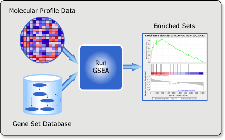

# GSEA principle

- All genes are sorted according to some criterion (e.g. differential expression p-value, correlation of expression with other variables, …).
- Each graph compares the ranked gene list with one reference class (e.g. one biological process).
- Black bars denote genes belonging to the reference class.
- The green curve estimates, at each level i, the degree of over-representation of the reference genes in the i top-ranking genes.

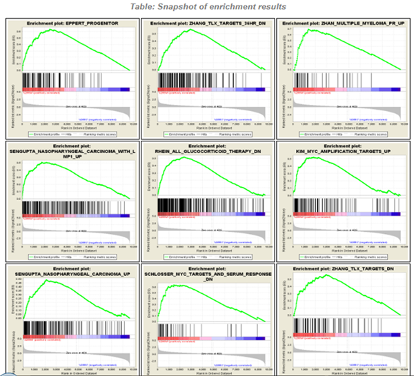